# Zadanie domowe 1

Wojciech Kretowicz

17 kwietnia 2020

# Glance at the data

```
## Data '38' file 'description.xml' found in cache.
```

```
## Data '38' file 'dataset.arff' found in cache.
```

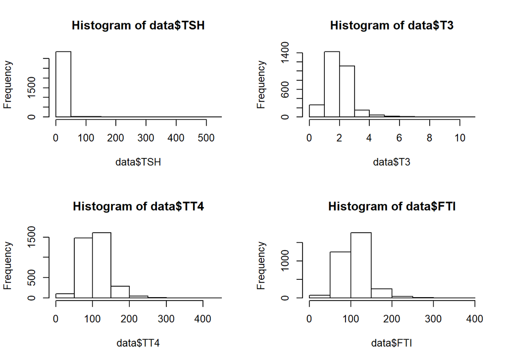

```r
par(mfrow=c(2,2))
hist(data$TSH)
hist(data$T3)
hist(data$TT4)
hist(data$FTI)
```

# Preprocessing

## Laboratory tests

First, I checked laboratory tests to find out, what are possible values of hormones in a human body. Taking very large margin, I chose following values:

- $TSH < 100$
- $T3 < 30$
- $TT4 < 400$
- $FTI < 400$

## Distributions

Furthermore, I transformed all numerical values with boxcox trasformation, resulting in these distributions:

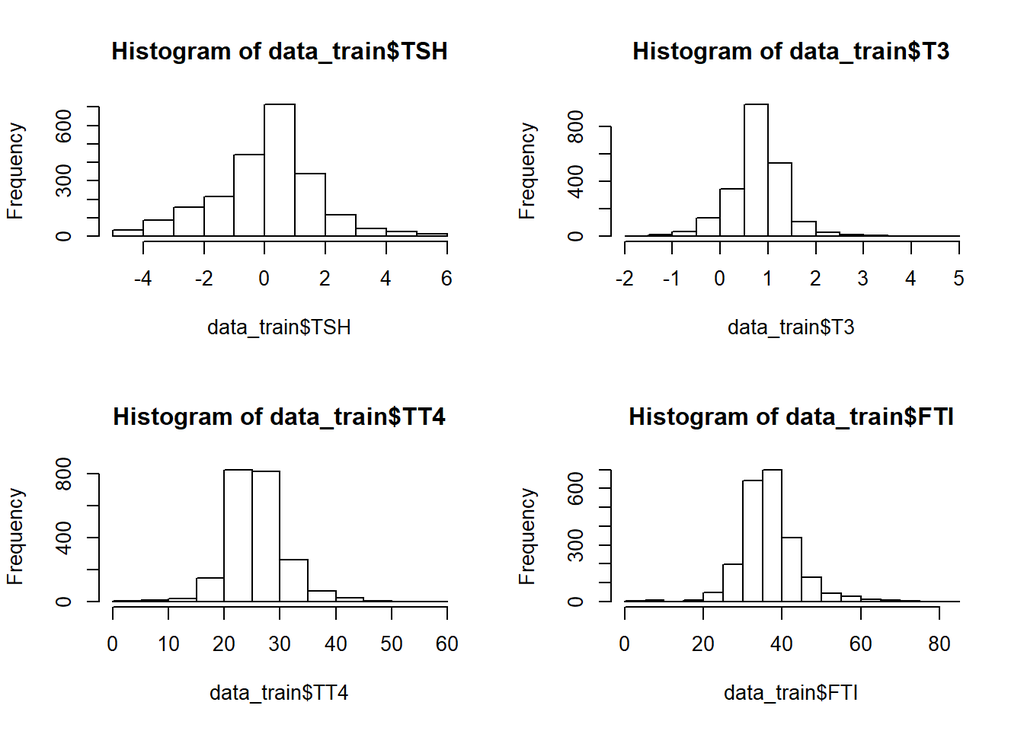

```r
par(mfrow=c(2,2))
hist(data_train$TSH)
hist(data_train$T3)
hist(data_train$TT4)
hist(data_train$FTI)
```

## Missing values

At this moment missing values and features with suffix “measured” are negligible - there are only 2 features with missing values with aroung 3% of missing values. I used mice package with ‘pmm’ method to fill these. Them I dropped all features with suffix ‘measure’.

## Black box

I have constructed black box with “ranger” to have a comparison and explained it to make accumulated dependency plot and feature importance. It showed me the most important variables in this task.

```r
library(DALEX)
library(mlr)
black_box = mlr::makeLearner('classif.ranger', predict.type = 'prob')
```

### Results

On 5-cv:

- AUPRC: $95.9 +- 1.4$
- AUROC: $99.5 +- 2.5$

On test data:

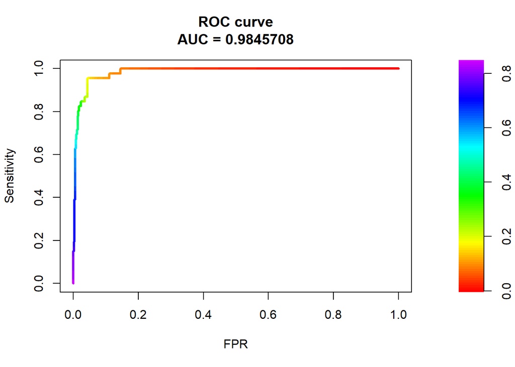

```r
roc <- roc.curve(scores.class0 = fg, scores.class1 = bg, curve = T)
plot(roc)
```

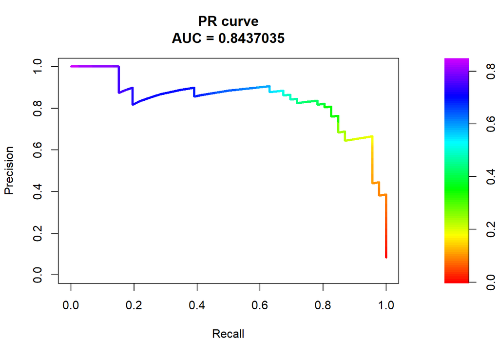

```r
set.seed(77)

pr <- pr.curve(scores.class0 = fg, scores.class1 = bg, curve = T)
plot(pr)
```

### Explaining black box

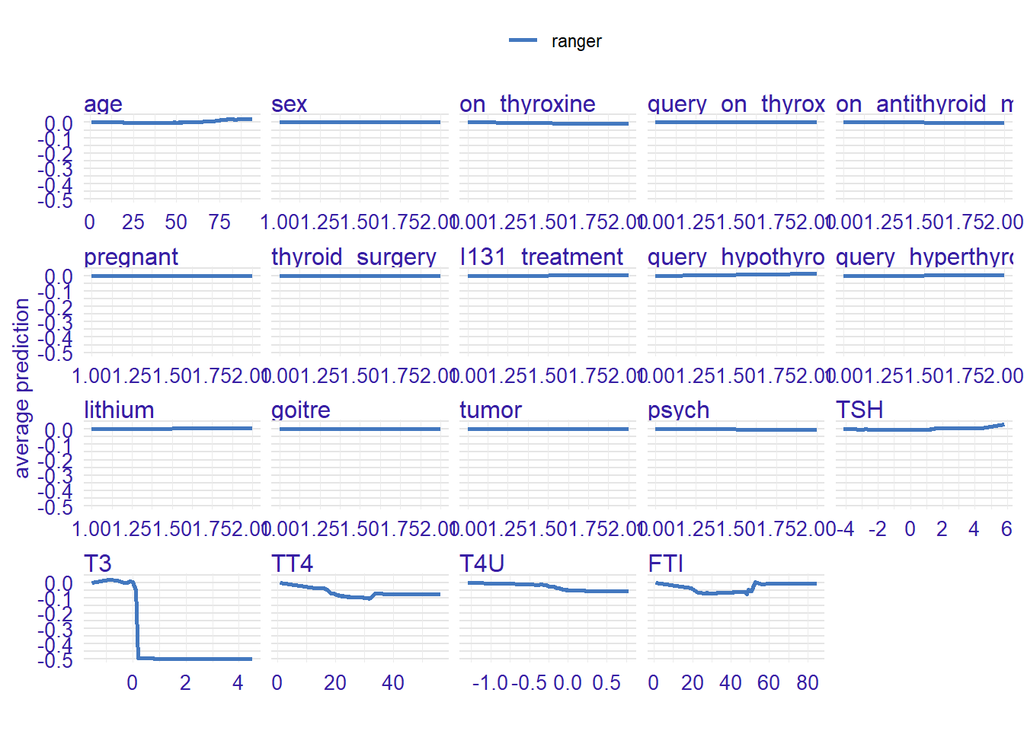

```r
exp = explain(black_box, data_train[,-25],data_train$Class, verbose=FALSE)
library(ingredients)
acc = ingredients::accumulated_dependency(exp, variables = c("age", "sex", "on_thyroxine", "query_on_thyroxine", "on_antithyroid_medication", "pregnant", "thyroid_surgery", "I131_treatment", "query_hypothyroid",         "query_hyperthyroid", "lithium", "goitre", "tumor", "psych", "TSH", "T3", "TT4", "T4U", "FTI"))
plot(acc)
```

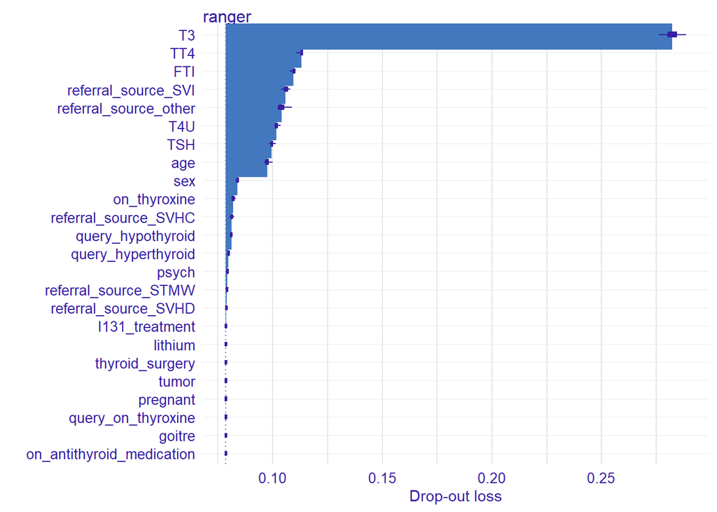

```r
fi = ingredients::feature_importance(exp)
plot(fi)
```

## Model

I have chosen logistic regression and rpart for modelling, because both are easily interpretable. However, rpart had much better results.

## Feature engineering

I added few more features based on cross val scores of auprc and black box explanation:

- $T3^2$
- $T4U^2$
- $TT4^2$
- $T3/FTI$

## Tuning

I used random search for tuning rpart.

## Results

After all I have got on 5-cv:

- AUPRC: $92.9 +- 4.1$
- AUROC: $96.2 +- 2.9$

And on the test set:

- AUPRC: $91.3$
- AUROC: $49.1$?

```
## $minsplit
## [1] 9
##
## $minbucket
## [1] 3
##
## $cp
## [1] 0.01444444
##
## $maxcompete
## [1] 6
##
## $usesurrogate
## [1] 0
##
## $maxdepth
## [1] 10
```

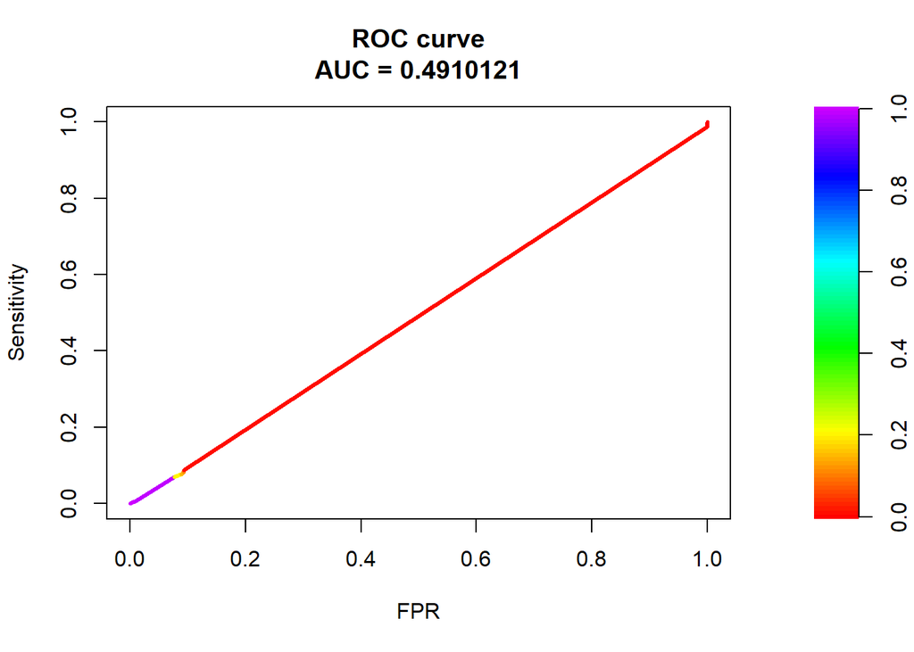

```r
# ROC Curve
roc <- roc.curve(scores.class0 = fg, scores.class1 = bg, curve = T)
plot(roc)
```

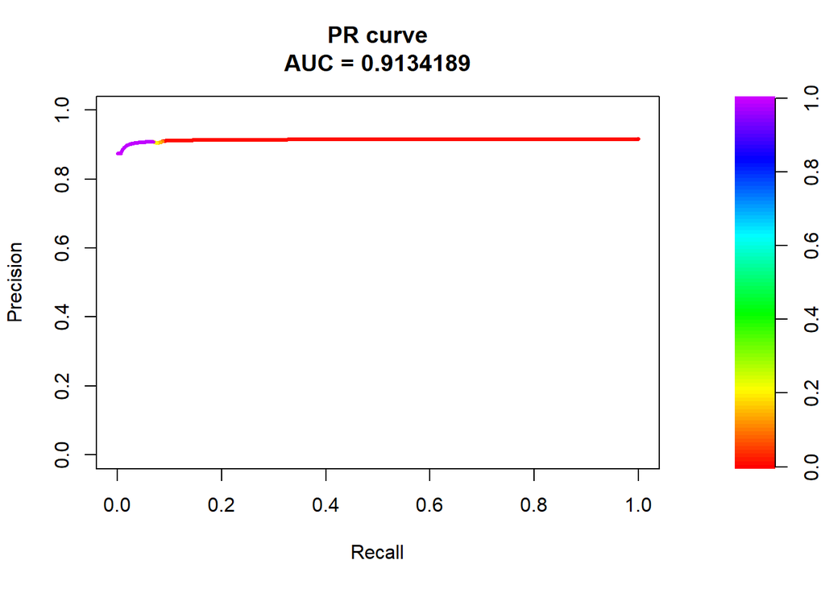

```r
# PR Curve
pr <- pr.curve(scores.class0 = fg, scores.class1 = bg, curve = T)
plot(pr)
```

# Conclusions